# Bayesian Statistics the Fun Way: Exercises

# Chapter 5

1. You want to use the beta distribution to determine whether or not a coin you have is a fair coin-meaning that the coin gives you heads and tails equally. You flip the coin 10 times and get 4 heads and 6 tails. Using the beta distribution, what is the probability that the coin will land on heads more than 60 percent of the time?

```r
# Setting beta distribution parameters
alpha <- 4
beta <- 6

# Finding sum of probabilities from .6 to 1
# About 10% chance of landing on heads at least 60% of the time
integrate(function(x) dbeta(x, alpha, beta), .6, 1)
```

```
## 0.09935258 with absolute error < 1.1e-15
```

2. You flip the coin 10 more times and now have 9 heads and 11 tails total. What is the probability that the coin is fair, using our definition of fair, give or take 5 percent?

```r
alpha <- 9
beta <- 11

# Integrating all possible probabilities between 45-55%
# About 31% chance of coin being fair
integrate(function(x) dbeta(x, alpha, beta), .45, .55)
```

```
## 0.30988 with absolute error < 3.4e-15
```

3. Data is the best way to become more confident in your assertions. You flip the coin 200 more times and end up with 109 heads and 111 tails. Now what is the probability that the coin is fair, give or take 5 percent?

```r
alpha <- 109
beta <- 111

# About 86% chance of coin being fair
integrate(function(x) dbeta(x, alpha, beta), .45, .55)
```

```
## 0.8589371 with absolute error < 9.5e-15
```

# Chapter 6

2. What is the probability that a random person picked from the population is female and is not color blind?

```r
# Product rule for dependent probabilities
# P(Female) * P(Not Color Blind | Female)
p_female <- .5
p_ncb_female <- .995
p_female * p_ncb_female
```

```
## [1] 0.4975
```

3. What is the probability that a male who received the flu vaccine in 2010 is either color blind or has GBS?

```r
# Sum rule for independent probabilities
# Events are not mutually exclusive
p_cb_male <- .08
p_gbs_vac <- (3 / 100000)
(p_cb_male + p_gbs_vac) - (p_cb_male * p_gbs_vac)
```

```
## [1] 0.0800276
```

# Chapter 7

1. Kansas City, despite its name, sits on the border of two US states: Missouri and Kansas. The Kansas City metropolitan area consists of 15 counties, 9 in Missouri and 6 in Kansas. The entire state of Kansas has 105 counties and Missouri has 114. Use Bayes' theorem to calculate the probability that a relative who just moved to a county in the Kansas City metropolitan area also lives in a county in Kansas. Make sure to show P(Kansas) (assuming your relative either lives in Kansas or Missouri), P(Kansas City metropolitan area), and P(Kansas City metropolitan area | Kansas).

```r
# P(Kansas | KC)
# P(KC | Kansas) * P(Kansas) / P(KC)
p_kansas <- 105 / (105 + 114)
p_kc <- 15 / (105 + 114)
p_kc_kansas <- 6 / 105

(p_kc_kansas * p_kansas) / (p_kc)
```

```
## [1] 0.4
```

2. A deck of cards has 52 cards with suits that are either red or black. There are four aces in a deck of cards: two red and two black. You remove a red ace from the deck and shuffle the cards. Your friend pulls a black card. What is the probability that it is an ace?

```r
# P(Ace | Black)
# P(Black | Ace) * P(Ace) / P(Black)
p_ace <- 3 / 51
p_black <- 26 / 51
p_black_ace <- 2 / 3

(p_black_ace * p_ace) / p_black
```

```
## [1] 0.07692308
```

# Chapter 8

1. As mentioned, you might disagree with the original probability assigned to the likelihood: $P(broken window, open front door, missing laptop | robbed) = \frac{3}{10}$

How much does this change our strength in believing H1 over H2?

```r
# Let's try making the likelihood 10x smaller
likelihood <- 3 / 100
prior <- 1 / 1000

# Find ratio of updated hypothesis 1 to hypothesis 2
# Our ratio has shrunk 10x in step with the likelihood
(prior * likelihood) / (1 / 21900000)
```

```
## [1] 657
```

2. How unlikely would you have to believe being robbed is-our prior for H1-in order for the ratio of H1 to H2 to be even?

```r
# Have to multiply denominator of original prior by original ratio amount
prior <- 1 / (1000 * 657)

(prior * likelihood) / (1 / 21900000)
```

```
## [1] 1
```

# Chapter 9

1. A friend finds a coin on the ground, flips it, and gets six heads in a row and then one tails. Give the beta distribution that describes this. Use integration to determine the probability that the true rate of flipping heads is between 0.4 and 0.6, reflecting that the coin is reasonably fair.

```r
alpha <- 6
beta <- 1

integrate(function(x) dbeta(x, alpha, beta), .4, .6)
```

```
## 0.04256 with absolute error < 4.7e-16
```

2. Come up with a prior probability that the coin is fair. Use a beta distribution such that there is at least a 95 percent chance that the true rate of flipping heads is between 0.4 and 0.6.

```r
prior_alpha <- 55
prior_beta <- 55

integrate(function(x) dbeta(x, prior_alpha + 6, prior_beta + 1), .4, .6)
```

```
## 0.9527469 with absolute error < 1.5e-11
```

3. Now see how many more heads (with no more tails) it would take to convince you that there is a reasonable chance that the coin is not fair. In this case, let's say that this means that our belief in the rate of the coin being between 0.4 and 0.6 drops below 0.5.

```r
more_heads <- 23

integrate(function(x) dbeta(x, prior_alpha + 6 + more_heads, prior_beta + 1), .4, .6)
```

```
## 0.4954059 with absolute error < 5.2e-11
```

# Chapter 10

1. It's possible to get errors that don't quite cancel out the way we want. In the Fahrenheit temperature scale, 98.6 degrees is the normal body temperature and 100.4 degrees is the typical threshold for a fever. Say you are taking care of a child that feels warm and seems sick, but you take repeated readings from the thermometer and they all read between 99.5 and 100.0 degrees: warm, but not quite a fever. You try the thermometer yourself and get several readings between 97.5 and 98. What could be wrong with the thermometer?

**The thermometer could be under-reading temperatures.**

2. Given that you feel healthy and have traditionally had a very consistently normal temperature, how could you alter the measurements 100, 99.5, 99.6, and 100.2 to estimate if the child has a fever?

**Add on somewhere between .5 and 1 degree to all measurements.**

# Chapter 11

1. One of the benefits of variance is that squaring the differences makes the penalties exponential. Give some examples of when this would be a useful property.

**Provides more of a penalty for really spread out data.**

2. Calculate the mean, variance, and standard deviation for the following values: 1, 2, 3, 4, 5, 6, 7, 8, 9, 10.

```r
example_vector <- c(1, 2, 3, 4, 5, 6, 7, 8, 9, 10)

# Mean
mean(example_vector)
```

```
## [1] 5.5
```

```r
# Variance
var(example_vector)
```

```
## [1] 9.166667
```

```r
# Standard Deviation
sd(example_vector)
```

```
## [1] 3.02765
```

# Chapter 12

1. What is the probability of observing a value five sigma greater than the mean or more?

```r
# Integrate from 5 to a reasonably large number
integrate(function(x) dnorm(x, 0, 1), 5, 100)
```

```
## 2.88167e-07 with absolute error < 5.6e-07
```

2. A fever is any temperature greater than 100.4 degrees Fahrenheit. Given the following measurements, what is the probability that the patient has a fever? 100.0, 99.8, 101.0, 100.5, 99.7

```r
temp_vector <- c(100, 99.8, 101, 100.5, 99.7)

integrate(function(x) dnorm(x, mean = mean(temp_vector),
                            sd = sd(temp_vector)),
          100.4, 200)
```

```
## 0.3563509 with absolute error < 1.1e-08
```

3. Suppose in Chapter 11 we tried to measure the depth of a well by timing coin drops and got the following values: 2.5, 3, 3.5, 4, 2 The distance an object falls can be calculated (in meters) with the following formula: distance = 1/2 x G x time2 where G is 9.8 m/s/s. What is the probability that the well is over 500 meters deep?

```r
well_vector <- c(2.5, 3, 3.5, 4, 2)

time <- sqrt((500 * 2) / 9.8)

integrate(function(x) dnorm(x, mean = mean(well_vector),
                            sd = sd(well_vector)),
          time, 200)
```

```
## 7.825278e-20 with absolute error < 1.6e-19
```

4. What is the probability there is no well (i.e., the well is really 0 meters deep)? You'll notice that probability is higher than you might expect, given your observation that there is a well. There are two good explanations for this probability being higher than it should. The first is that the normal distribution is a poor model for our measurements; the second is that, when making up numbers for an example, I chose values that you likely wouldn't see in real life. Which is more likely to you?

```r
dnorm(0, mean = mean(well_vector), sd = sd(well_vector))
```

```
## [1] 0.000376747
```

# Chapter 13

1. Using the code example for plotting the PDF on page 127, plot the CDF and quantile functions.

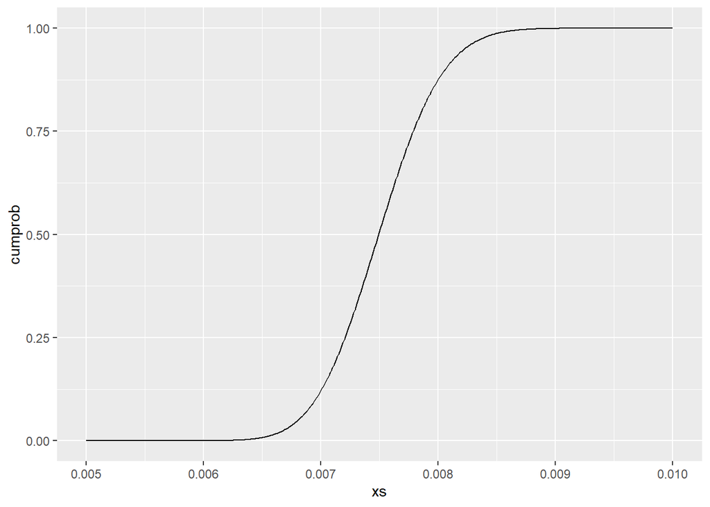

```r
example <- tibble(xs = seq(0.005, 0.01, by = 0.00001)) %>%
  mutate(cumprob = pbeta(xs, 300, 40000 - 300),
         quantile = qbeta(xs, 300, 40000 - 300))

# CDF Plot
example %>%
  ggplot(aes(x = xs, y = cumprob)) +
  geom_line()
```

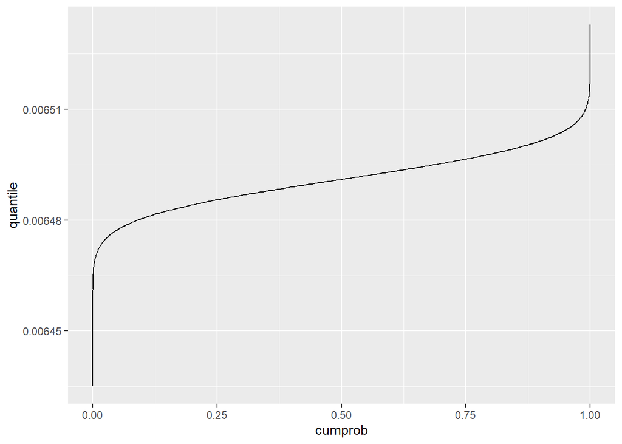

```r
# Quantile Plot
example %>%
  ggplot(aes(x = cumprob, y = quantile)) +
  geom_line()
```

```r
snow_vector <- c(7.8, 9.4, 10.0, 7.9, 9.4, 7.0, 7.0, 7.1, 8.9, 7.4)

# Lower bound
qnorm(.025, mean = mean(snow_vector),
      sd = sd(snow_vector))
```

```
## [1] 5.965923
```

```r
# Upper bound
qnorm(.975, mean = mean(snow_vector),
      sd = sd(snow_vector))
```

```
## [1] 10.41408
```

3. A child is going door to door selling candy bars. So far she has visited 30 houses and sold 10 candy bars. She will visit 40 more houses today. What is the 95 percent confidence interval for how many candy bars she will sell the rest of the day?

```r
# Lower bound
lb <- qbeta(.025, shape1 = 10, shape2 = 20)
# Upper bound
ub <- qbeta(.975, shape1 = 10, shape2 = 20)

# Putting bounds on scale of houses left
lb * 40
```

```
## [1] 7.175346
```

```r
ub * 40
```

```
## [1] 20.33293
```

# Chapter 14

1. Suppose you're playing air hockey with some friends and flip a coin to see who starts with the puck. After playing 12 times, you realize that the friend who brings the coin almost always seems to go first: 9 out of 12 times. Some of your other friends start to get suspicious. Define prior probability distributions for the following beliefs: One person who weakly believes that the friend is cheating and the true rate of coming up heads is closer to 70 percent. One person who very strongly trusts that the coin is fair and provided a 50 percent chance of coming up heads. One person who strongly believes the coin is biased to come up heads 70 percent of the time.

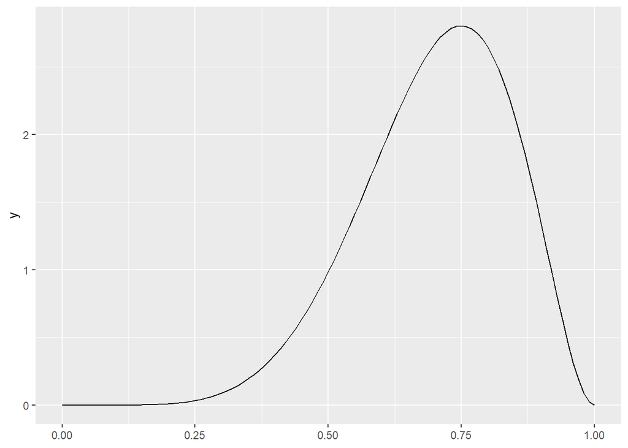

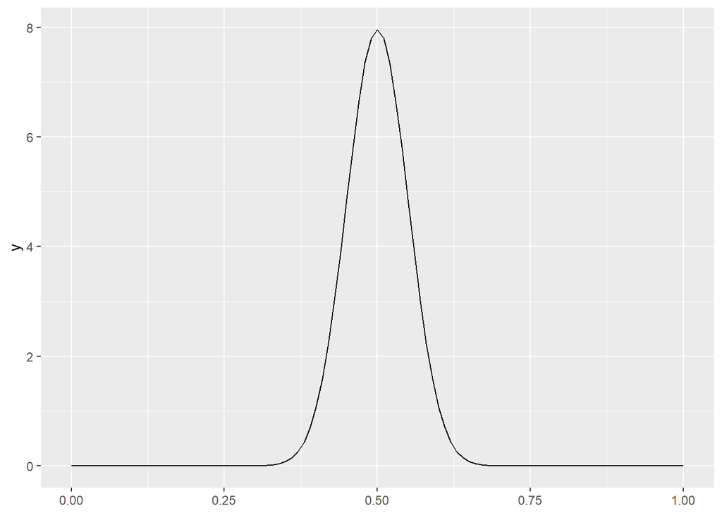

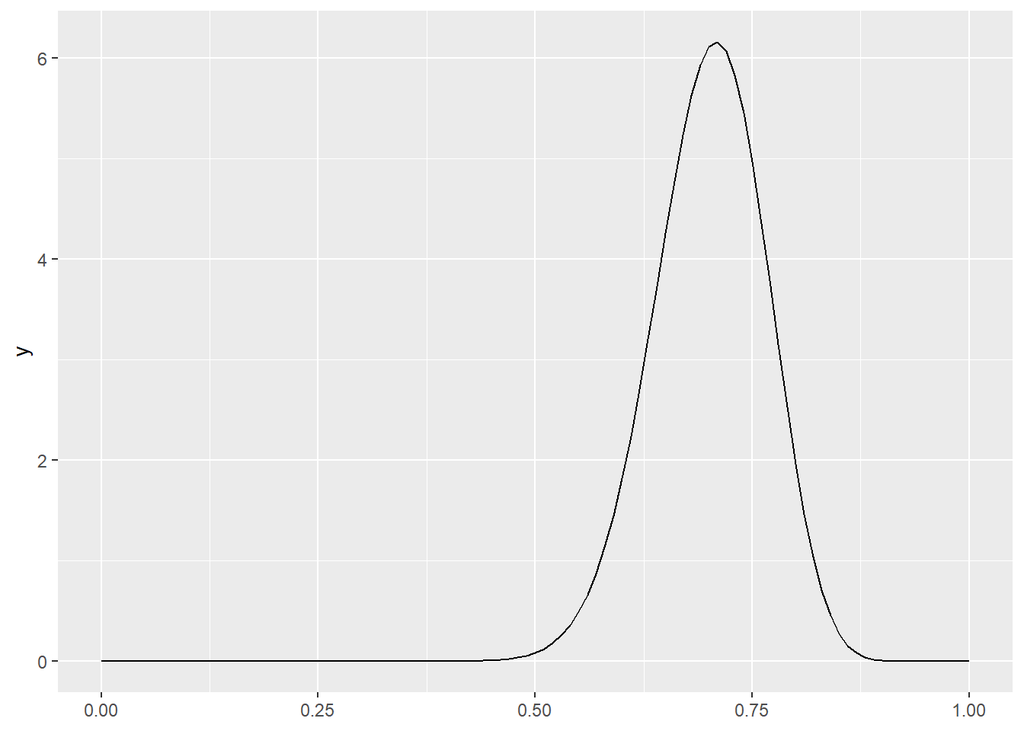

```r
# Creating some fake priors and plotting them
priors <- list(weak_bias = c(7, 3),
               very_strong_fair = c(50, 50),
               strong_bias = c(35, 15))

map(priors,
    ~ ggplot() +
      stat_function(fun = function(x) dbeta(x, .x[1], .x[2])))
```

2. To test the coin, you flip it 20 more times and get 9 heads and 11 tails. Using the priors you calculated in the previous question, what are the updated posterior beliefs in the true rate of flipping a heads in terms of the 95 percent confidence interval?

```r
# Updating initial flips
heads <- 9 + 9
tails <- 3 + 11

# Updating prior beliefs
updated_beliefs <- map(priors, ~ c(.x[1] + heads, .x[2] + tails))

map(updated_beliefs, ~ c(qbeta(.025, .x[1], .x[2]),
                         qbeta(.975, .x[1], .x[2])))
```

```
## $weak_bias
## [1] 0.4450478 0.7368320
##
## $very_strong_fair
## [1] 0.4301357 0.5997323
##
## $strong_bias
## [1] 0.5404147 0.7455052
```